# Tugas Praktikum 6 & 7 MPDW

### Packages

```r
library(ggplot2)
library(tsibble)
library(tseries)
library(MASS)
library(forecast)
library(TSA)
library(TTR)
library(aTSA)
library(graphics)
library(readxl)
library(dplyr)
library(lmtest)
```

# Data Bangkitan

## Pembangkitan Data

```r
set.seed(99)
ma2 <- arima.sim(list(order = c(0,0,2), ma = c(0.55,0.65)), n = 286)+4
```

Data kemudian dibagi menjadi data latih dan data uji dengan proporsi 80:20 (209 data latih : 52 data uji).

```r
ma2 <- ma2[-c(1:25)]
ma2.train <- ma2[1:209]
ma2.test <- ma2[210:261]
```

## Eksplorasi Data

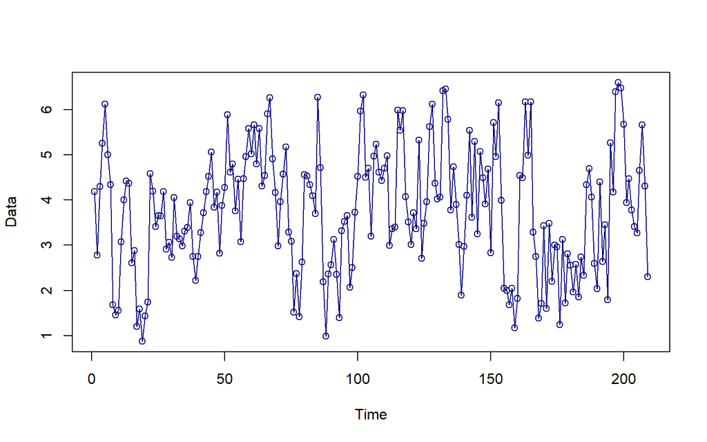

```r
plot(ma2.train, col = "navyblue", lwd = 1, type = "o", xlab = "Time", ylab = "Data")
```

Berdasarkan plot data deret waktu di atas, terlihat data cenderung stasioner dalam rataan dan ragam. Data stasioner dalam rataan karena menyebar/bergerak di sekitar nilai tengahnya dan dikatakan stasioner dalam ragam karena memiliki lebar pita yang cenderung sama. Selain dengan plot data deret waktu, dilakukan pengecekan stasioneritas data dengan plot ACF dan uji ADF.

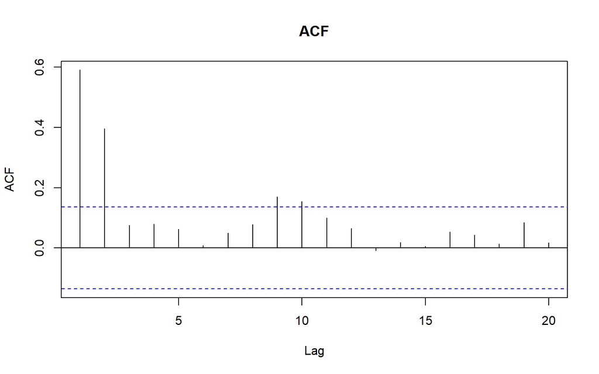

```r
acf(ma2.train, main="ACF", lag.max=20)
```

```r
tseries::adf.test(ma2.train)
```

```
##
##  Augmented Dickey-Fuller Test
##
## data:  ma2.train
## Dickey-Fuller = -5.4698, Lag order = 5, p-value = 0.01
## alternative hypothesis: stationary
```

```r
#stasioner
```

$H_0$ : Data tidak stasioner dalam rataan $H_1$ : Data stasioner dalam rataan

Berdasarkan uji ADF, diperoleh nilai statistik Dickey-Fuller sebesar -5,4698 dengan p-value sebesar 0,01. Karena p-value (0,01) < taraf signifikansi 5%, maka tolak $H_0$. Sehingga, terdapat cukup bukti untuk menyatakan bahwa data ma2.train stasioner.

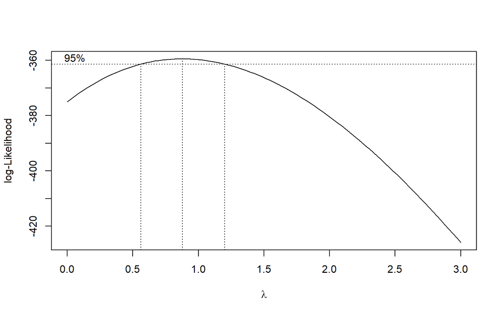

```r
index <- seq(1:209)
bc <- boxcox(ma2.train~index, lambda = seq(0, 3, by = 1))
```

```r
lambda <- bc$x[which.max(bc$y)]
lambda
```

```
## [1] 0.8787879
```

```r
ci_lambda <- bc$x[bc$y > max(bc$y) - 0.5 * qchisq(0.95, 1)]
c(Batas_Bawah = min(ci_lambda), Batas_Atas = max(ci_lambda))
```

```
## Batas_Bawah  Batas_Atas
##   0.5757576   1.1818182
```

## Spesifikasi Model

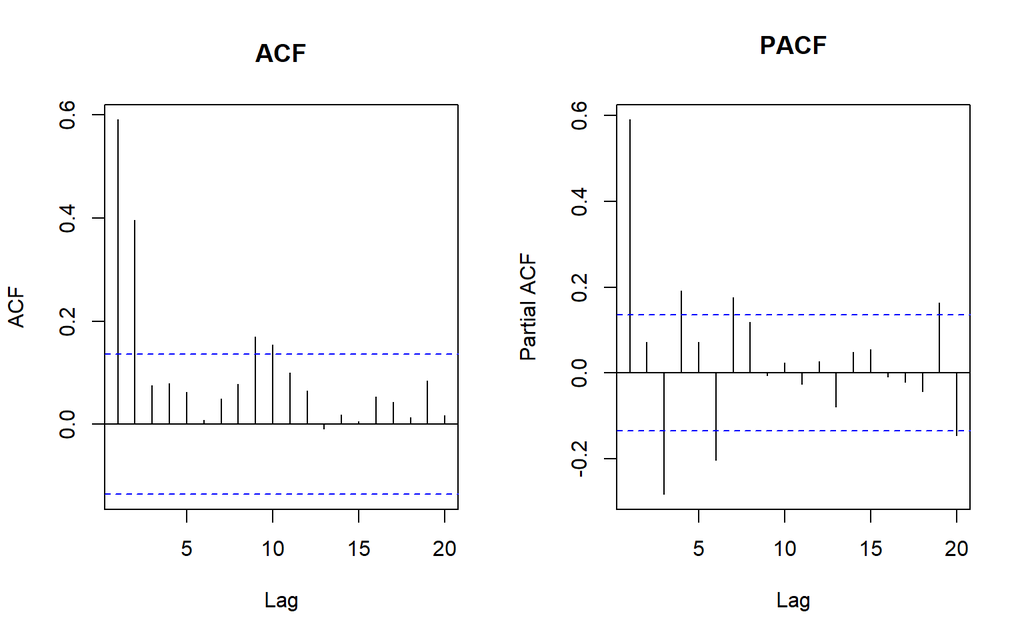

```r
par(mfrow = c(1,2))
acf(ma2.train, main="ACF", lag.max=20)
pacf(ma2.train, main="PACF", lag.max=20)
```

```r
par(mfrow = c(1,1))
```

```r
eacf(ma2.train)
```

```
## AR/MA
##   0 1 2 3 4 5 6 7 8 9 10 11 12 13
## 0 x x o o o o o o x x o  o  o  o
## 1 o x x o o o o o o o o  o  o  o
## 2 x x x o o o o o o o o  o  o  o
## 3 x x o o o o o o o o o  o  o  o
## 4 x x x o o x o o o o o  o  o  o
## 5 x x x o o x x o o o o  o  o  o
## 6 x x x o o x x o o o o  o  o  o
## 7 x x x x x x x o o o o  o  o  o
```

Dari pola segitiga EACF, diperoleh model tentatif ARIMA(0,0,2), ARIMA(1,0,3), ARIMA(2,0,3), dan ARIMA(3,0,3).

## Pendugaan Parameter

```r
model1.ma2 <- Arima(ma2.train, order=c(0,0,2), method="ML")
summary(model1.ma2)
```

```
## Series: ma2.train
## ARIMA(0,0,2) with non-zero mean
##
## Coefficients:
##          ma1     ma2    mean
##       0.6363  0.6505  3.7719
## s.e.  0.0569  0.0481  0.1550
##
## sigma^2 = 0.9822:  log likelihood = -293.8
## AIC=595.6   AICc=595.79   BIC=608.96
##
## Training set error measures:
##                        ME      RMSE       MAE       MPE     MAPE      MASE
## Training set -0.002505272 0.9839066 0.8074324 -10.10383 26.73673 0.8148464
##                    ACF1
## Training set 0.02458342
```

```r
lmtest::coeftest(model1.ma2)
```

```
##
## z test of coefficients:
##
##           Estimate Std. Error z value  Pr(>|z|)
## ma1       0.636318   0.056851  11.193 < 2.2e-16 ***
## ma2       0.650464   0.048123  13.517 < 2.2e-16 ***
## intercept 3.771892   0.155012  24.333 < 2.2e-16 ***
## ---
## Signif. codes:  0 '***' 0.001 '**' 0.01 '*' 0.05 '.' 0.1 ' ' 1
```

```r
model2.ma2 <- Arima(ma2.train, order=c(1,0,0), method="ML")
summary(model2.ma2)
```

```
## Series: ma2.train
## ARIMA(1,0,0) with non-zero mean
##
## Coefficients:
##          ar1    mean
##       0.5915  3.7721
## s.e.  0.0556  0.1835
##
## sigma^2 = 1.201:  log likelihood = -314.94
## AIC=635.89   AICc=636   BIC=645.91
##
## Training set error measures:
##                        ME     RMSE       MAE       MPE     MAPE      MASE
## Training set -0.001561386 1.090826 0.8845373 -12.18457 29.91688 0.8926592
##                     ACF1
## Training set -0.03681499
```

```r
lmtest::coeftest(model2.ma2)
```

```
##
## z test of coefficients:
##
##           Estimate Std. Error z value  Pr(>|z|)
## ar1       0.591506   0.055586  10.641 < 2.2e-16 ***
## intercept 3.772125   0.183454  20.562 < 2.2e-16 ***
## ---
## Signif. codes:  0 '***' 0.001 '**' 0.01 '*' 0.05 '.' 0.1 ' ' 1
```

```r
model3.ma2 <- Arima(ma2.train, order=c(1,0,3), method="ML")
summary(model3.ma2)
```

```
## Series: ma2.train
## ARIMA(1,0,3) with non-zero mean
##
## Coefficients:
##          ar1      ma1     ma2      ma3    mean
##       0.8839  -0.2284  0.1102  -0.5468  3.7724
## s.e.  0.1349   0.1532  0.1150   0.1088  0.1934
##
## sigma^2 = 0.9873:  log likelihood = -293.34
## AIC=598.68   AICc=599.09   BIC=618.73
##
## Training set error measures:
##                        ME      RMSE       MAE       MPE     MAPE      MASE
## Training set -0.002920241 0.9816872 0.8028791 -9.731746 26.42794 0.8102512
##                     ACF1
## Training set 0.001269068
```

```r
lmtest::coeftest(model3.ma2)
```

```
##
## z test of coefficients:
##
##           Estimate Std. Error z value  Pr(>|z|)
## ar1        0.88388    0.13491  6.5517  5.69e-11 ***
## ma1       -0.22837    0.15319 -1.4908    0.1360
## ma2        0.11016    0.11502  0.9578    0.3382
## ma3       -0.54681    0.10883 -5.0244  5.05e-07 ***
## intercept  3.77240    0.19343 19.5024 < 2.2e-16 ***
## ---
## Signif. codes:  0 '***' 0.001 '**' 0.01 '*' 0.05 '.' 0.1 ' ' 1
```

```r
model4.ma2 <- Arima(ma2.train, order=c(2,0,3), method="ML")
summary(model4.ma2)
```

```
## Series: ma2.train
## ARIMA(2,0,3) with non-zero mean
##
## Coefficients:
##          ar1     ar2      ma1     ma2      ma3    mean
##       0.8765  0.0058  -0.2226  0.1084  -0.5456  3.7725
## s.e.  0.2148  0.1279   0.2035  0.1215   0.1133  0.1938
##
## sigma^2 = 0.9922:  log likelihood = -293.34
## AIC=600.68   AICc=601.23   BIC=624.07
##
## Training set error measures:
##                        ME      RMSE       MAE       MPE     MAPE      MASE
## Training set -0.002929085 0.9816888 0.8027607 -9.747103 26.43253 0.8101318
##                     ACF1
## Training set 0.002723873
```

```r
lmtest::coeftest(model4.ma2)
```

```
##
## z test of coefficients:
##
##            Estimate Std. Error z value  Pr(>|z|)
## ar1        0.876526   0.214791  4.0808 4.487e-05 ***
## ar2        0.005805   0.127882  0.0454    0.9638
## ma1       -0.222563   0.203479 -1.0938    0.2740
## ma2        0.108364   0.121468  0.8921    0.3723
## ma3       -0.545608   0.113257 -4.8174 1.454e-06 ***
## intercept  3.772478   0.193840 19.4618 < 2.2e-16 ***
## ---
## Signif. codes:  0 '***' 0.001 '**' 0.01 '*' 0.05 '.' 0.1 ' ' 1
```

```r
model5.ma2 <- Arima(ma2.train, order=c(3,0,3), method="ML")
summary(model5.ma2)
```

```
## Series: ma2.train
## ARIMA(3,0,3) with non-zero mean
##
## Coefficients:
##          ar1      ar2     ar3      ma1     ma2      ma3    mean
##       0.9355  -0.2211  0.1428  -0.2825  0.2882  -0.5825  3.7744
## s.e.  0.2053   0.2388  0.1685   0.1959  0.2240   0.1369  0.1982
##
## sigma^2 = 0.9948:  log likelihood = -293.18
## AIC=602.35   AICc=603.07   BIC=629.09
##
## Training set error measures:
##                        ME      RMSE      MAE       MPE     MAPE      MASE
## Training set -0.003299839 0.9805651 0.803033 -9.826538 26.54804 0.8104065
##                      ACF1
## Training set -0.000717373
```

```r
lmtest::coeftest(model5.ma2)
```

```
##
## z test of coefficients:
##
##           Estimate Std. Error z value  Pr(>|z|)
## ar1        0.93547    0.20529  4.5569 5.192e-06 ***
## ar2       -0.22107    0.23883 -0.9257    0.3546
## ar3        0.14279    0.16854  0.8472    0.3969
## ma1       -0.28254    0.19594 -1.4420    0.1493
## ma2        0.28819    0.22400  1.2866    0.1982
## ma3       -0.58245    0.13694 -4.2532 2.107e-05 ***
## intercept  3.77439    0.19822 19.0417 < 2.2e-16 ***
## ---
## Signif. codes:  0 '***' 0.001 '**' 0.01 '*' 0.05 '.' 0.1 ' ' 1
```

```r
hasil_model <- data.frame(
  Model = c("ARIMA(0,0,2)","ARIMA(1,0,0)","ARIMA(1,0,3)",
            "ARIMA(2,0,3)","ARIMA(3,0,3)"),
  AIC = c(AIC(model1.ma2), AIC(model2.ma2), AIC(model3.ma2),
          AIC(model4.ma2), AIC(model5.ma2)),
  BIC = c(BIC(model1.ma2), BIC(model2.ma2), BIC(model3.ma2),
          BIC(model4.ma2), BIC(model5.ma2))
)
hasil_model
```

```
##          Model      AIC      BIC
## 1 ARIMA(0,0,2) 595.5957 608.9650
## 2 ARIMA(1,0,0) 635.8859 645.9129
## 3 ARIMA(1,0,3) 598.6790 618.7330
## 4 ARIMA(2,0,3) 600.6769 624.0732
## 5 ARIMA(3,0,3) 602.3504 629.0891
```

Berdasarkan pendugaan parameter di atas, nilai AIC terkecil dimiliki oleh model ARIMA(0,0,2) dan parameter model ARIMA(0,0,2) juga seluruhnya signifikan sehingga model yang dipilih adalah model ARIMA(0,0,2).

```r
Mod(polyroot(c(1, coef(model4.ma2)[grepl("^ma", names(coef(model4.ma2)))])))
```

```
## [1] 1.176342 1.248224 1.248224
```

```r
Mod(polyroot(c(1, coef(model5.ma2)[grepl("^ma", names(coef(model5.ma2)))])))
```

```
## [1] 1.232080 1.180459 1.180459
```

```r
Mod(polyroot(c(1, coef(model1.ma2)[grepl("^ma", names(coef(model1.ma2)))])))
```

```
## [1] 1.239905 1.239905
```

Seluruh model memiliki modulus akar MA di atas 1 (invertible), namun karena ARIMA(0,0,2) sudah memiliki AIC terendah **dan** seluruh parameter signifikan, model ini tetap menjadi pilihan terbaik.

## Analisis Sisaan

### Eksplorasi Sisaan

```r
sisaan.ma2 <- model1.ma2$residuals
par(mfrow=c(2,2))
car::qqPlot(sisaan.ma2)
```

```
## [1] 87 85
```

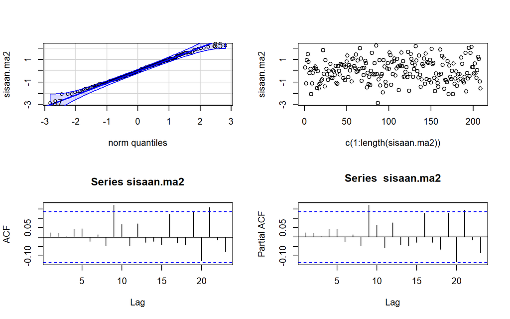

```r
plot(c(1:length(sisaan.ma2)), sisaan.ma2)
acf(sisaan.ma2)
pacf(sisaan.ma2)
```

```r
par(mfrow = c(1,1))
```

Berdasarkan hasil eksplorasi sisaan model ARIMA(0,0,2), normal Q-Q plot menunjukkan bahwa sebagian besar titik sisaan mengikuti garis diagonal sehingga sisaan secara umum mendekati distribusi normal. Plot sisaan terhadap waktu menunjukkan bahwa sisaan menyebar secara acak di sekitar nilai nol dan tidak menunjukkan pola tertentu. Pada plot ACF dan PACF, sebagian besar nilai autokorelasi dan autokorelasi parsial berada dalam batas interval kepercayaan 95%, meskipun terdapat beberapa spike pada lag tertentu. Secara umum, tidak terlihat pola autokorelasi yang sistematis pada sisaan. Selanjutnya, kondisi sisaan perlu dikonfirmasi menggunakan uji Ljung-Box untuk memastikan bahwa sisaan telah memenuhi asumsi white noise.

### Uji Formal

```r
#1) Sisaan Menyebar Normal
ks.test(sisaan.ma2,"pnorm")
```

```
##
##  Asymptotic one-sample Kolmogorov-Smirnov test
##
## data:  sisaan.ma2
## D = 0.039735, p-value = 0.8962
## alternative hypothesis: two-sided
```

```r
#gagal tolak H0 > sisaan menyebar normal
```

Selain dengan eksplorasi, asumsi tersebut dapat diuji menggunakan uji formal. Pada tahapan ini uji formal yang digunakan untuk normalitas adalah uji Kolmogorov-Smirnov (KS). Hipotesis pada uji KS adalah sebagai berikut.

$H_0$ : Sisaan menyebar normal $H_1$ : Sisaan tidak menyebar normal

Berdasarkan uji KS tersebut, didapat *p-value* sebesar 0.8962 yang lebih besar dari taraf nyata 5% sehingga gagal tolak $H_0$ dan menandakan bahwa sisaan menyebar normal. Hal ini sesuai dengan hasil eksplorasi menggunakan plot kuantil-kuantil normal. Dengan demikian, dapat disimpulkan bahwa sisaan model ARIMA(0,0,2) berdistribusi normal.

```r
#2) Sisaan saling bebas/tidak ada autokorelasi
Box.test(sisaan.ma2, type = "Ljung")
```

```
##
##  Box-Ljung test
##
## data:  sisaan.ma2
## X-squared = 0.12813, df = 1, p-value = 0.7204
```

```r
#gagal tolak H0 > sisaan saling bebas
```

Selanjutnya akan dilakukan uji formal untuk kebebasan sisaan menggunakan uji Ljung-Box. Hipotesis yang digunakan adalah sebagai berikut.

$H_0$ : Sisaan saling bebas $H_1$ : Sisaan tidak tidak saling bebas

Berdasarkan uji Ljung-Box tersebut, didapat *p-value* sebesar 0.7204 yang lebih besar dari taraf nyata 5% sehingga gagal tolak $H_0$ dan menandakan bahwa sisaan saling bebas. Dengan demikian, tidak terdapat cukup bukti untuk menyatakan bahwa sisaan saling berkorelasi. Oleh karena itu, sisaan model ARIMA(0,0,2) dapat dianggap saling bebas atau tidak memiliki autokorelasi yang signifikan.

```r
#3) Sisaan homogen
Box.test((sisaan.ma2)^2, type = "Ljung")
```

```
##
##  Box-Ljung test
##
## data:  (sisaan.ma2)^2
## X-squared = 3.3531, df = 1, p-value = 0.06708
```

```r
#gagal tolak H0 > sisaan homogen
```

Hipotesis yang digunakan untuk uji kehomogenan ragam adalah sebagai berikut.

$H_0$ : Ragam sisaan homogen $H_1$ : Ragam sisaan tidak homogen

```r
#4) Nilai tengah sisaan sama dengan nol
t.test(sisaan.ma2, mu = 0, conf.level = 0.95)
```

```
##
##  One Sample t-test
##
## data:  sisaan.ma2
## t = -0.036723, df = 208, p-value = 0.9707
## alternative hypothesis: true mean is not equal to 0
## 95 percent confidence interval:
##  -0.1369994  0.1319888
## sample estimates:
##    mean of x
## -0.002505272
```

```r
#gagal tolak h0 > nilai tengah sisaan sama dengan 0
```

Terakhir, dengan uji-t, akan dicek apakah nilai tengah sisaan sama dengan nol. Hipotesis yang diujikan sebagai berikut.

$H_0$ : nilai tengah sisaan sama dengan 0 $H_1$ : nilai tengah sisaan tidak sama dengan 0

## Overfitting

```r
model1a.ma2 <- Arima(ma2.train, order=c(1,0,2), method="ML")
summary(model1a.ma2)
```

```
## Series: ma2.train
## ARIMA(1,0,2) with non-zero mean
##
## Coefficients:
##          ar1     ma1     ma2    mean
##       0.0581  0.5999  0.6465  3.7711
## s.e.  0.1060  0.0830  0.0519  0.1615
##
## sigma^2 = 0.9855:  log likelihood = -293.66
## AIC=597.32   AICc=597.61   BIC=614.03
##
## Training set error measures:
##                        ME      RMSE      MAE       MPE     MAPE      MASE
## Training set -0.002531774 0.9831586 0.807247 -9.823746 26.58934 0.8146593
##                     ACF1
## Training set 0.002632873
```

```r
lmtest::coeftest(model1a.ma2)
```

```
##
## z test of coefficients:
##
##           Estimate Std. Error z value  Pr(>|z|)
## ar1       0.058070   0.106017  0.5477    0.5839
## ma1       0.599861   0.082984  7.2287 4.877e-13 ***
## ma2       0.646486   0.051870 12.4636 < 2.2e-16 ***
## intercept 3.771083   0.161498 23.3506 < 2.2e-16 ***
## ---
## Signif. codes:  0 '***' 0.001 '**' 0.01 '*' 0.05 '.' 0.1 ' ' 1
```

```r
model1b.ma2 <- Arima(ma2.train, order=c(0,0,3), method="ML")
summary(model1b.ma2)
```

```
## Series: ma2.train
## ARIMA(0,0,3) with non-zero mean
##
## Coefficients:
##          ma1     ma2     ma3    mean
##       0.6573  0.6835  0.0383  3.7711
## s.e.  0.0691  0.0804  0.0734  0.1611
##
## sigma^2 = 0.9855:  log likelihood = -293.66
## AIC=597.32   AICc=597.62   BIC=614.04
##
## Training set error measures:
##                        ME      RMSE       MAE       MPE     MAPE      MASE
## Training set -0.002525993 0.9831722 0.8074177 -9.834116 26.60102 0.8148315
##                     ACF1
## Training set 0.003205705
```

```r
lmtest::coeftest(model1b.ma2)
```

```
##
## z test of coefficients:
##
##           Estimate Std. Error z value Pr(>|z|)
## ma1       0.657314   0.069053  9.5190   <2e-16 ***
## ma2       0.683525   0.080402  8.5013   <2e-16 ***
## ma3       0.038334   0.073415  0.5221   0.6016
## intercept 3.771114   0.161120 23.4056   <2e-16 ***
## ---
## Signif. codes:  0 '***' 0.001 '**' 0.01 '*' 0.05 '.' 0.1 ' ' 1
```

```r
overfitting <- data.frame(
  Model = c("ARIMA(1,0,2)","ARIMA(0,0,2)", "ARIMA(0,0,3)"),
  AIC   = c(AIC(model1a.ma2), AIC(model1.ma2), AIC(model1b.ma2)),
  BIC   = c(BIC(model1a.ma2), BIC(model1.ma2), BIC(model1b.ma2))
)
overfitting
```

```
##          Model      AIC      BIC
## 1 ARIMA(1,0,2) 597.3175 614.0292
## 2 ARIMA(0,0,2) 595.5957 608.9650
## 3 ARIMA(0,0,3) 597.3243 614.0360
```

Berdasarkan kedua model hasil overfitting di atas, model ARIMA(1,0,2) dan ARIMA(0,0,3) memiliki AIC yang lebih besar dibandingkan dengan model ARIMA(0,0,2) dan parameter tambahan pada kedua model tersebut tidak signifikan. Oleh karena itu, model ARIMA(0,0,2) tetap digunakan untuk melakukan peramalan.

## Peramalan

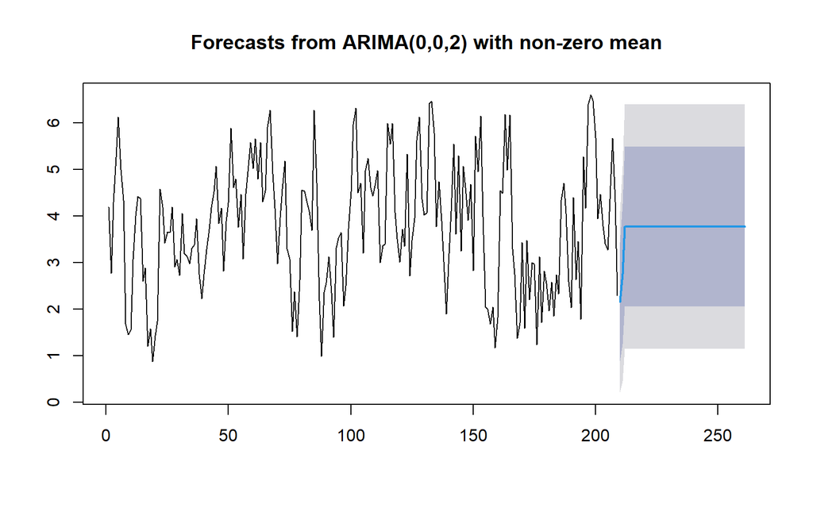

```r
ramalan <- forecast::forecast(model1.ma2, h = 52)
data.ramalan <- ramalan$mean
plot(ramalan)
```

Berdasarkan hasil plot ramalan di atas, dapat dilihat bahwa hasil ramalan menggunakan model ARIMA(0,0,2) mengalami penyesuaian pada awal periode ramalan, kemudian cenderung stabil hingga akhir periode. Nilai ramalan selanjutnya berada di sekitar nilai rata-rata sebesar 3,8. Selain itu, terlihat adanya interval kepercayaan yang mengelilingi nilai ramalan, yang menunjukkan adanya ketidakpastian dalam hasil peramalan. Selanjutnya, dapat dicari nilai akurasi antara hasil ramalan dengan data uji sebagai berikut.

```r
perbandingan <- matrix(data=c(ma2.test, data.ramalan), nrow = 52, ncol = 2)
colnames(perbandingan) <- c("Aktual","Hasil Forecast")
perbandingan
```

```
##           Aktual Hasil Forecast
##  [1,]  2.0076604       2.160698
##  [2,]  3.3632575       2.759084
##  [3,]  3.6855632       3.771892
##  [4,]  5.8042185       3.771892
##  [5,]  7.1282577       3.771892
##  [6,]  5.4818366       3.771892
##  [7,]  5.2580305       3.771892
##  [8,]  3.4248094       3.771892
##  [9,]  2.6875795       3.771892
## [10,]  2.6050357       3.771892
## [11,]  1.0402451       3.771892
## [12,]  3.6924334       3.771892
## [13,]  5.6522845       3.771892
## [14,]  6.5655548       3.771892
```

[output cut: 38 more lines]

```r
accuracy(data.ramalan, ma2.test)
```

```
##                ME     RMSE      MAE      MPE     MAPE
## Test set 0.220346 1.625248 1.258261 54.14771 112.4017
```

# Data Real

Digunakan data kurs yang dalam hal ini hanya digunakan data 261 periode awal

```r
data<- read_excel("D:\\IPB\\PPT Kuliah - IPB\\Semester 5 Dept Statistika\\MPDW\\Dataset\\usd_idr_2021.xlsx")
data<- data[1:261,]

str(data)
```

```
## tibble [261 × 2] (S3: tbl_df/tbl/data.frame)
##  $ Date : POSIXct[1:261], format: "2021-01-01" "2021-01-04" ...
##  $ Close: chr [1:261] "139323740234375" "140225009765625" "13931400390625" "13930.0" ...
```

```r
head(data)
```

```
## # A tibble: 6 × 2
##   Date                Close
##   <dttm>              <chr>
## 1 2021-01-01 00:00:00 139323740234375
## 2 2021-01-04 00:00:00 140225009765625
## 3 2021-01-05 00:00:00 13931400390625
## 4 2021-01-06 00:00:00 13930.0
## 5 2021-01-07 00:00:00 13951.5
## 6 2021-01-08 00:00:00 138929775390625
```

```r
normalisasi_skala <- function(v){
  v <- as.numeric(v)
  while (!is.na(v) && v >= 20000) {
    v <- v/10
  }
  v
}

datakurs <- data %>%
  mutate(Close = as.numeric(as.character(Close))) %>%
  rowwise() %>%
  mutate(Close = normalisasi_skala(Close)) %>%
  ungroup() %>%
  arrange(Date)
data.ts <- ts(datakurs$Close)
summary(datakurs$Close)
```

```
##    Min. 1st Qu.  Median    Mean 3rd Qu.    Max.
##   13828   14220   14318   14311   14444   14674
```

## Eksplorasi Data

### Plot Data Penuh

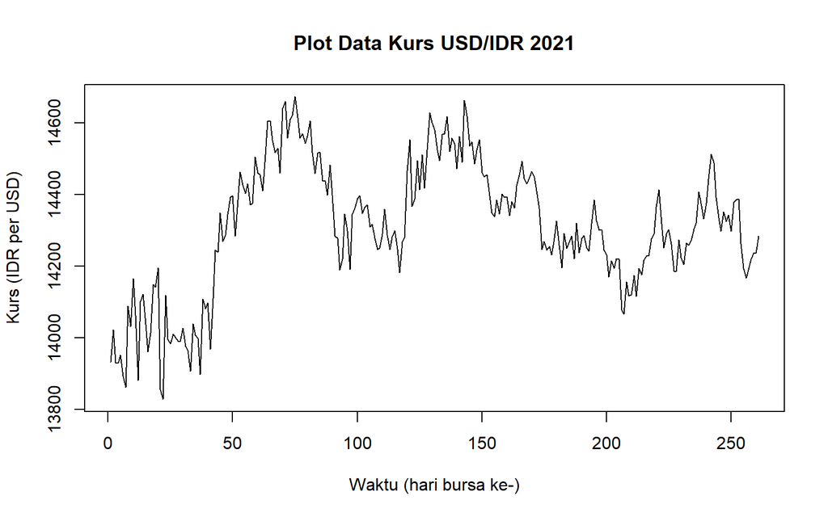

```r
plot.ts(data.ts, lty = 1, xlab = "Waktu (hari bursa ke-)",
        ylab = "Kurs (IDR per USD)", main = "Plot Data Kurs USD/IDR 2021")
```

Berdasarkan plot data deret waktu, terlihat bahwa data cenderung mengalami fluktuasi dengan beberapa pola kenaikan dan penurunan pada periode pengamatan. Berdasarkan pola data, pembagian data latih dan data uji ditetapkan dengan proporsi 80:20, dengan 209 observasi sebagai data latih dan 52 observasi sebagai data uji.

### Plot Data Latih dan Uji

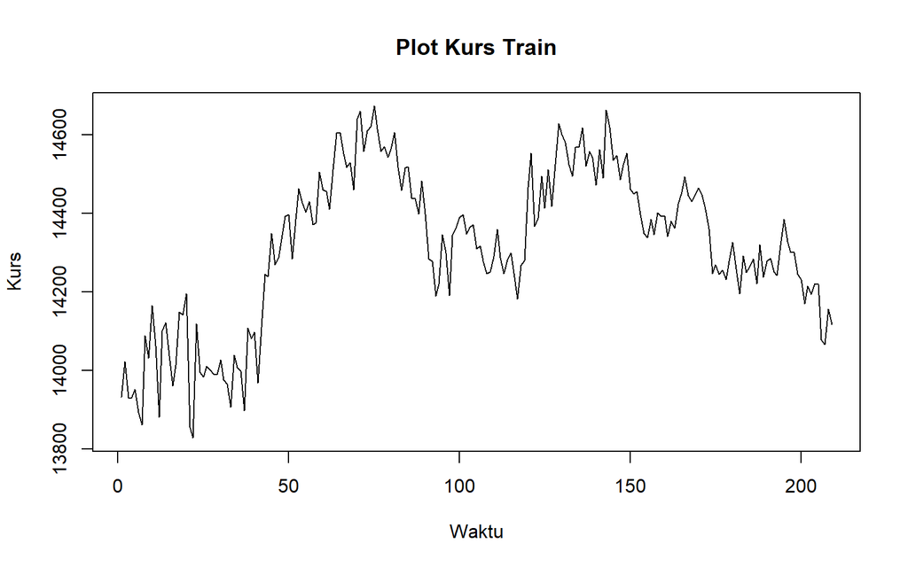

```r
n       <- length(data.ts)
n_test  <- 52
n_train <- n - n_test

kurstrain <- datakurs$Close[1:n_train]
train.ts  <- ts(kurstrain)
plot.ts(train.ts, lty=1, xlab="Waktu", ylab="Kurs", main="Plot Kurs Train")
```

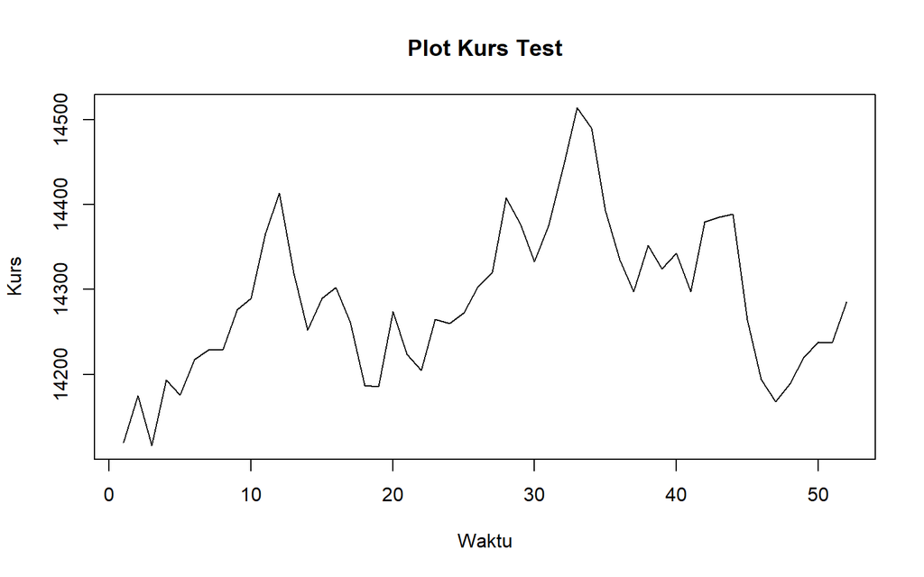

```r
kurstest <- datakurs$Close[(n_train+1):n]
test.ts  <- ts(kurstest)
plot.ts(test.ts, lty=1, xlab="Waktu", ylab="Kurs", main="Plot Kurs Test")
```

Berdasarkan plot data deret waktu pada data latih, data menunjukkan perubahan fluktuasi di sekitar nilai tengah yang tidak konstan sehingga terdapat indikasi ketidakstasioneran. Indikasi tersebut kemudian dikonfirmasi menggunakan uji ADF.

## Uji Stasioneritas Data

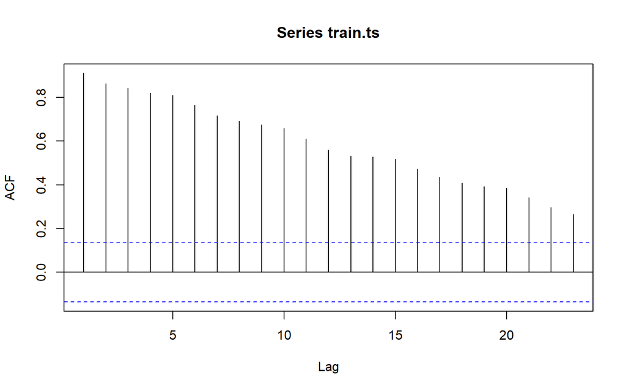

```r
acf(train.ts)
```

```r
tseries::adf.test(train.ts)
```

```
##
##  Augmented Dickey-Fuller Test
##
## data:  train.ts
## Dickey-Fuller = -1.3936, Lag order = 5, p-value = 0.8303
## alternative hypothesis: stationary
```

### Uji ADF

```r
tseries::adf.test(train.ts)
```

```
##
##  Augmented Dickey-Fuller Test
##
## data:  train.ts
## Dickey-Fuller = -1.3936, Lag order = 5, p-value = 0.8303
## alternative hypothesis: stationary
```

$H_0$ : Data tidak stasioner dalam rataan $H_1$ : Data stasioner dalam rataan

Berdasarkan uji ADF tersebut, didapat *p-value* sebesar 0.8303 yang lebih besar dari taraf nyata 5% sehingga gagal tolak $H_0$ dan menandakan bahwa data tidak stasioner dalam rataan. Hal ini sesuai dengan hasil eksplorasi menggunakan plot time series dan plot ACF, sehingga ketidakstasioneran model kedepannya harus ditangani.

### Plot Box-Cox

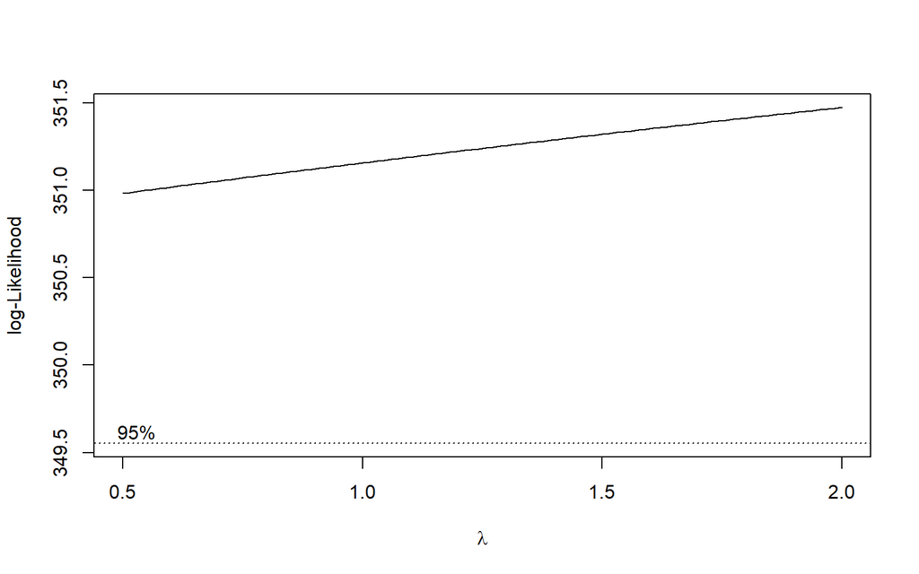

```r
index <- seq(1:n_train)
bc <- boxcox(train.ts ~ index, lambda = seq(0.5, 2, by = 0.1))
```

```r
lambda_opt <- bc$x[which.max(bc$y)]
lambda_opt
```

```
## [1] 2
```

```r
ci_lambda <- bc$x[bc$y > max(bc$y) - 0.5 * qchisq(0.95, df = 1)]
ci_lower <- min(ci_lambda)
ci_upper <- max(ci_lambda)
c(Batas_Bawah = ci_lower, Batas_Atas = ci_upper)
```

```
## Batas_Bawah  Batas_Atas
##         0.5         2.0
```

Nilai $\lambda$ optimum berada di ujung rentang pencarian (=2), dengan selang kepercayaan 95% $[0{,}5,\ 2{,}0]$ — memuat nilai satu, sehingga data cukup stasioner dalam ragam (transformasi Box-Cox tidak diperlukan).

## Penanganan Ketidakstasioneran Data

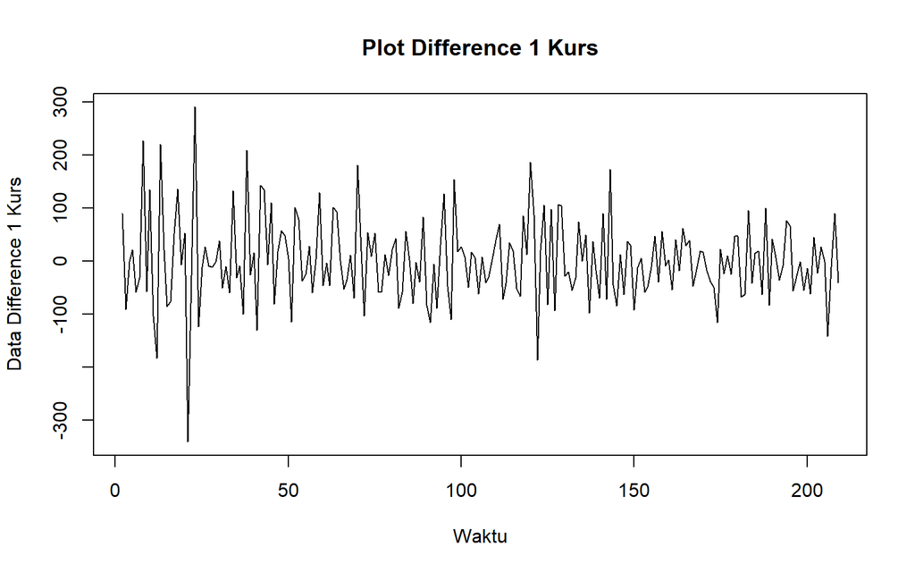

```r
train.diff <- diff(train.ts, differences = 1)
plot.ts(train.diff, lty=1, xlab="Waktu", ylab="Data Difference 1 Kurs",
        main="Plot Difference 1 Kurs")
```

```r
acf(train.diff)
```

[output not shown]

```r
tseries::adf.test(train.diff)
```

```
##
##  Augmented Dickey-Fuller Test
##
## data:  train.diff
## Dickey-Fuller = -6.3258, Lag order = 5, p-value = 0.01
## alternative hypothesis: stationary
```

Berdasarkan plot data deret waktu pada difference 1, terlihat bahwa data bergerak dan berfluktuasi di sekitar nilai tengah yang relatif konstan, yaitu di sekitar nol, serta tidak menunjukkan adanya tren maupun pola musiman yang jelas. Hal ini mengindikasikan bahwa data sudah stasioner dalam rataan setelah dilakukan differencing orde pertama.

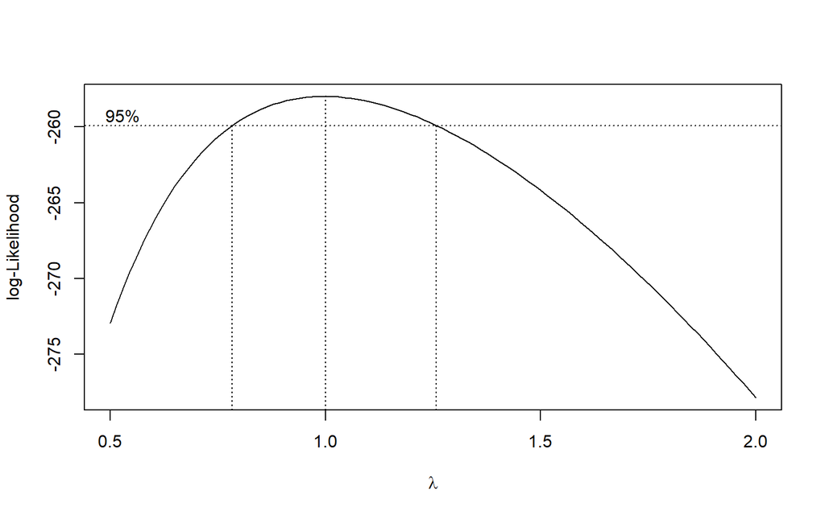

```r
index_diff <- seq(1:length(train.diff))
min_val <- min(train.diff)
if (min_val <= 0) {
  konstanta <- abs(min_val) + 1
  train.diff_shifted <- train.diff + konstanta
} else {
  train.diff_shifted <- train.diff
}
bc_diff <- boxcox(train.diff_shifted ~ index_diff, lambda = seq(0.5, 2, by = 0.1))
```

```r
lambda_opt_diff <- bc_diff$x[which.max(bc_diff$y)]
lambda_opt_diff
```

```
## [1] 1
```

```r
ci_lambda_diff <- bc_diff$x[bc_diff$y > max(bc_diff$y) - 0.5 * qchisq(0.95, df = 1)]
c(Batas_Bawah = min(ci_lambda_diff), Batas_Atas = max(ci_lambda_diff))
```

```
## Batas_Bawah  Batas_Atas
##   0.7878788   1.2575758
```

### Plot ACF

```r
acf(train.diff)
```

[output not shown]

### Uji ADF

```r
tseries::adf.test(train.diff)
```

```
##
##  Augmented Dickey-Fuller Test
##
## data:  train.diff
## Dickey-Fuller = -6.3258, Lag order = 5, p-value = 0.01
## alternative hypothesis: stationary
```

$H_0$ : Data tidak stasioner dalam rataan $H_1$ : Data stasioner dalam rataan

Berdasarkan uji ADF tersebut, didapat p-value sebesar 0.01 yang lebih kecil dari taraf nyata 5% sehingga tolak H0 atau data stasioner dalam rataan. Hal ini sesuai dengan hasil eksplorasi menggunakan plot time series dan plot ADF, sehingga dalam hal ini ketidakstasioneran data sudah berhasil ditangani dan data dapat dilanjutkan ke tahap pemodelan ARIMA.

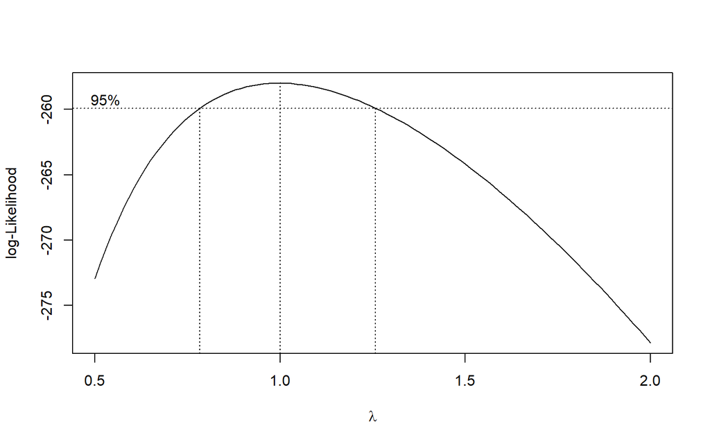

```r
library(MASS)

# 1. Sesuaikan panjang index karena differencing menghilangkan 1 observasi awal
index_diff <- seq(1:length(train.diff))

# 2. Cek apakah ada nilai negatif/nol. Jika ada, tambahkan konstanta (c)
# agar nilai minimum data menjadi > 0 (misalnya menjadi 1)
min_val <- min(train.diff)

if (min_val <= 0) {
  c <- abs(min_val) + 1
  train.diff_shifted <- train.diff + c
} else {
  train.diff_shifted <- train.diff
}

# 3. Plot Box-Cox pada data yang sudah di-shift
bc_diff <- boxcox(train.diff_shifted ~ index_diff, lambda = seq(0.5, 2, by = 0.1))
```

```r
# 4. Nilai lambda optimum (rounded)
lambda_opt_diff <- bc_diff$x[which.max(bc_diff$y)]
print(paste("Lambda optimum setelah diff:", lambda_opt_diff))
```

```
## [1] "Lambda optimum setelah diff: 1"
```

```r
# 5. Selang kepercayaan 95% untuk lambda
ci_lambda_diff <- bc_diff$x[bc_diff$y > max(bc_diff$y) - 0.5 * qchisq(0.95, df = 1)]

# Batas bawah dan batas atas
ci_lower_diff <- min(ci_lambda_diff)
ci_upper_diff <- max(ci_lambda_diff)

c(Batas_Bawah = ci_lower_diff, Batas_Atas = ci_upper_diff)
```

```
## Batas_Bawah  Batas_Atas
##   0.7878788   1.2575758
```

## Identifikasi Model

```r
acf(train.diff)
```

[output not shown]

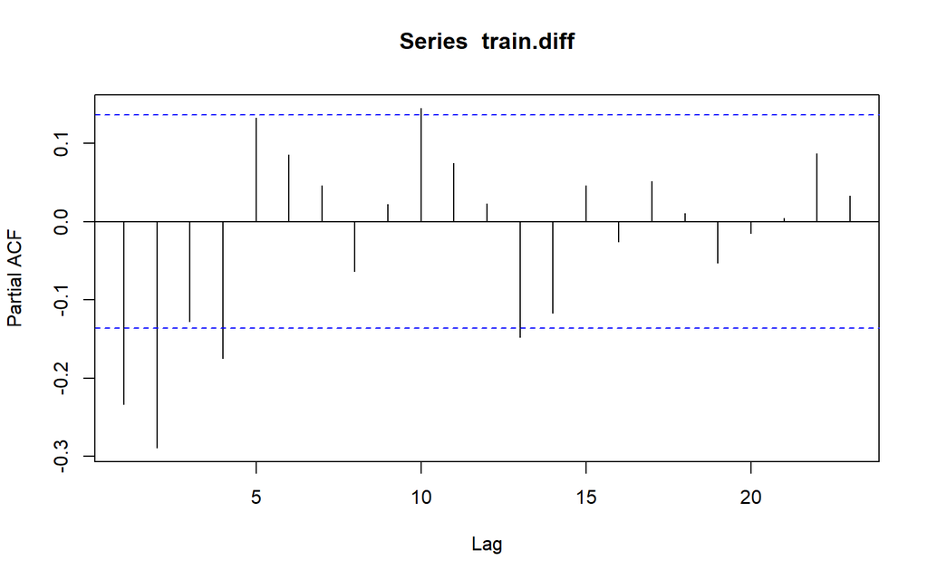

```r
pacf(train.diff)
```

```r
eacf(train.diff)
```

```
## AR/MA
##   0 1 2 3 4 5 6 7 8 9 10 11 12 13
## 0 x x o o x o o o o x o  o  o  o
## 1 x x o o x o o o o x o  o  x  o
## 2 x x o o x o o o o x o  o  o  o
## 3 x x x x x o o o o o o  o  o  o
## 4 x x x o x o o o o o o  o  o  o
## 5 x o x o o x o o o o o  o  o  o
## 6 x o x x o x o o o o o  o  o  o
## 7 x x o x x x o o o o o  o  o  o
```

## Pendugaan Parameter Model Tentatif

```r
model1.da <- Arima(train.diff, order=c(0,0,1), method="ML", include.mean = FALSE)
summary(model1.da); lmtest::coeftest(model1.da)
```

```
## Series: train.diff
## ARIMA(0,0,1) with zero mean
##
## Coefficients:
##           ma1
##       -0.4471
## s.e.   0.0702
##
## sigma^2 = 5481:  log likelihood = -1190.09
## AIC=2384.19   AICc=2384.24   BIC=2390.86
##
## Training set error measures:
##                    ME     RMSE      MAE      MPE     MAPE      MASE       ACF1
## Training set 1.577399 73.85652 56.50671 167.5099 220.0758 0.6008188 0.08204998
```

```
##
## z test of coefficients:
##
##      Estimate Std. Error z value  Pr(>|z|)
## ma1 -0.447065   0.070188 -6.3696 1.896e-10 ***
## ---
## Signif. codes:  0 '***' 0.001 '**' 0.01 '*' 0.05 '.' 0.1 ' ' 1
```

```r
model2.da <- Arima(train.diff, order=c(1,0,0), method="ML", include.mean = FALSE)
summary(model2.da); lmtest::coeftest(model2.da)
```

```
## Series: train.diff
## ARIMA(1,0,0) with zero mean
##
## Coefficients:
##           ar1
##       -0.2339
## s.e.   0.0675
##
## sigma^2 = 5839:  log likelihood = -1196.58
## AIC=2397.16   AICc=2397.22   BIC=2403.83
##
## Training set error measures:
##                    ME     RMSE      MAE      MPE     MAPE      MASE        ACF1
## Training set 1.127466 76.22683 57.18101 143.9901 162.1136 0.6079884 -0.06714608
```

```
##
## z test of coefficients:
##
##      Estimate Std. Error z value  Pr(>|z|)
## ar1 -0.233901   0.067503 -3.4651 0.0005301 ***
## ---
## Signif. codes:  0 '***' 0.001 '**' 0.01 '*' 0.05 '.' 0.1 ' ' 1
```

```r
model3.da <- Arima(train.diff, order=c(1,0,1), method="ML", include.mean = FALSE)
summary(model3.da); lmtest::coeftest(model3.da)
```

```
## Series: train.diff
## ARIMA(1,0,1) with zero mean
##
## Coefficients:
##          ar1      ma1
##       0.2397  -0.6142
## s.e.  0.1166   0.0863
##
## sigma^2 = 5397:  log likelihood = -1187.98
## AIC=2381.95   AICc=2382.07   BIC=2391.96
##
## Training set error measures:
##                  ME     RMSE      MAE     MPE     MAPE     MASE       ACF1
## Training set 1.7632 73.11029 55.79647 150.193 190.1992 0.593267 0.02626029
```

```
##
## z test of coefficients:
##
##      Estimate Std. Error z value  Pr(>|z|)
## ar1  0.239664   0.116556  2.0562   0.03976 *
## ma1 -0.614244   0.086276 -7.1196 1.083e-12 ***
## ---
## Signif. codes:  0 '***' 0.001 '**' 0.01 '*' 0.05 '.' 0.1 ' ' 1
```

```r
model4.da <- Arima(train.diff, order=c(1,0,2), method="ML", include.mean = FALSE)
summary(model4.da); lmtest::coeftest(model4.da)
```

```
## Series: train.diff
## ARIMA(1,0,2) with zero mean
##
## Coefficients:
##           ar1     ma1      ma2
##       -0.5186  0.1896  -0.4055
## s.e.   0.1920  0.1759   0.0756
##
## sigma^2 = 5257:  log likelihood = -1184.79
## AIC=2377.59   AICc=2377.79   BIC=2390.94
##
## Training set error measures:
##                    ME     RMSE      MAE      MPE    MAPE      MASE         ACF1
## Training set 1.697461 71.98316 55.13517 145.2722 198.507 0.5862355 -0.003005284
```

```
##
## z test of coefficients:
##
##     Estimate Std. Error z value  Pr(>|z|)
## ar1 -0.51855    0.19204 -2.7002  0.006929 **
## ma1  0.18960    0.17586  1.0781  0.280982
## ma2 -0.40551    0.07563 -5.3617 8.242e-08 ***
## ---
## Signif. codes:  0 '***' 0.001 '**' 0.01 '*' 0.05 '.' 0.1 ' ' 1
```

```r
model5.da <- Arima(train.diff, order=c(2,0,1), method="ML", include.mean = FALSE)
summary(model5.da); lmtest::coeftest(model5.da)
```

```
## Series: train.diff
## ARIMA(2,0,1) with zero mean
##
## Coefficients:
##          ar1      ar2      ma1
##       0.0653  -0.2119  -0.4098
## s.e.  0.1433   0.0823   0.1367
##
## sigma^2 = 5277:  log likelihood = -1185.17
## AIC=2378.34   AICc=2378.53   BIC=2391.69
##
## Training set error measures:
##                    ME     RMSE     MAE      MPE     MAPE      MASE         ACF1
## Training set 1.652889 72.11576 54.9891 136.0257 191.7882 0.5846825 -0.007075461
```

```
##
## z test of coefficients:
##
##      Estimate Std. Error z value Pr(>|z|)
## ar1  0.065291   0.143339  0.4555 0.648748
## ar2 -0.211921   0.082322 -2.5743 0.010044 *
## ma1 -0.409802   0.136720 -2.9974 0.002723 **
## ---
## Signif. codes:  0 '***' 0.001 '**' 0.01 '*' 0.05 '.' 0.1 ' ' 1
```

```r
model6.da <- Arima(train.diff, order=c(2,0,2), method="ML", include.mean = FALSE)
summary(model6.da); lmtest::coeftest(model6.da)
```

```
## Series: train.diff
## ARIMA(2,0,2) with zero mean
##
## Coefficients:
##           ar1      ar2     ma1      ma2
##       -0.5198  -0.0068  0.1894  -0.3995
## s.e.   0.1984   0.1394  0.1866   0.1447
##
## sigma^2 = 5283:  log likelihood = -1184.79
## AIC=2379.59   AICc=2379.88   BIC=2396.28
##
## Training set error measures:
##                    ME     RMSE      MAE      MPE    MAPE      MASE         ACF1
## Training set 1.692444 71.98281 55.13092 145.7474 199.278 0.5861904 -0.001745768
```

```
##
## z test of coefficients:
##
##      Estimate Std. Error z value Pr(>|z|)
## ar1 -0.519846   0.198425 -2.6199 0.008797 **
## ar2 -0.006795   0.139363 -0.0488 0.961112
## ma1  0.189365   0.186630  1.0147 0.310270
## ma2 -0.399548   0.144736 -2.7605 0.005771 **
## ---
## Signif. codes:  0 '***' 0.001 '**' 0.01 '*' 0.05 '.' 0.1 ' ' 1
```

```r
model7.da <- Arima(train.diff, order=c(3,0,2), method="ML", include.mean = FALSE)
summary(model7.da); lmtest::coeftest(model7.da)
```

```
## Series: train.diff
## ARIMA(3,0,2) with zero mean
##
## Coefficients:
##           ar1      ar2      ar3     ma1      ma2
##       -0.7052  -0.1113  -0.1084  0.3752  -0.3803
## s.e.   0.2412   0.1749   0.1096  0.2321   0.1273
##
## sigma^2 = 5285:  log likelihood = -1184.33
## AIC=2380.66   AICc=2381.08   BIC=2400.69
##
## Training set error measures:
##                    ME     RMSE      MAE      MPE     MAPE      MASE
## Training set 1.659008 71.81976 54.99873 136.8901 193.2336 0.5847848
##                      ACF1
## Training set -0.009292059
```

```
##
## z test of coefficients:
##
##     Estimate Std. Error z value Pr(>|z|)
## ar1 -0.70519    0.24117 -2.9240 0.003456 **
## ar2 -0.11126    0.17490 -0.6361 0.524698
## ar3 -0.10840    0.10955 -0.9894 0.322447
## ma1  0.37519    0.23214  1.6162 0.106052
## ma2 -0.38031    0.12729 -2.9878 0.002810 **
## ---
## Signif. codes:  0 '***' 0.001 '**' 0.01 '*' 0.05 '.' 0.1 ' ' 1
```

### Ringkasan AIC

```r
model_tentatif <- data.frame(
  Model = c("ARIMA(0,1,1)","ARIMA(1,1,0)","ARIMA(1,1,1)","ARIMA(1,1,2)",
            "ARIMA(2,1,1)","ARIMA(2,1,2)","ARIMA(3,1,2)"),
  AIC = c(AIC(model1.da),AIC(model2.da),AIC(model3.da),AIC(model4.da),
          AIC(model5.da),AIC(model6.da),AIC(model7.da)),
  BIC = c(BIC(model1.da),BIC(model2.da),BIC(model3.da),BIC(model4.da),
          BIC(model5.da),BIC(model6.da),BIC(model7.da))
)
model_tentatif
```

```
##          Model      AIC      BIC
## 1 ARIMA(0,1,1) 2384.185 2390.860
## 2 ARIMA(1,1,0) 2397.160 2403.835
## 3 ARIMA(1,1,1) 2381.952 2391.965
## 4 ARIMA(1,1,2) 2377.589 2390.939
## 5 ARIMA(2,1,1) 2378.336 2391.686
## 6 ARIMA(2,1,2) 2379.587 2396.275
## 7 ARIMA(3,1,2) 2380.661 2400.686
```

Sesuai kaidah pemilihan model yang telah diterapkan dengan benar pada Bagian Data Bangkitan — **AIC terkecil di antara model dengan seluruh parameter signifikan** — maka model yang seharusnya dipilih adalah:

$$\textbf{ARIMA(1,1,1)}\
(\text{AIC}=2381{,}952,\ \text{BIC}=2391{,}965)$$
## Analisis Sisaan

Model terbaik hasil identifikasi kemudian dicek asumsi sisaannya. Sisaan model ARIMA harus memenuhi asumsi normalitas, kebebasan sisaan, dan kehomogenan ragam. Diagnostik model dilakukan secara eksplorasi dan uji formal.

### Eksplorasi Sisaan Model ARIMA(1,1,1)

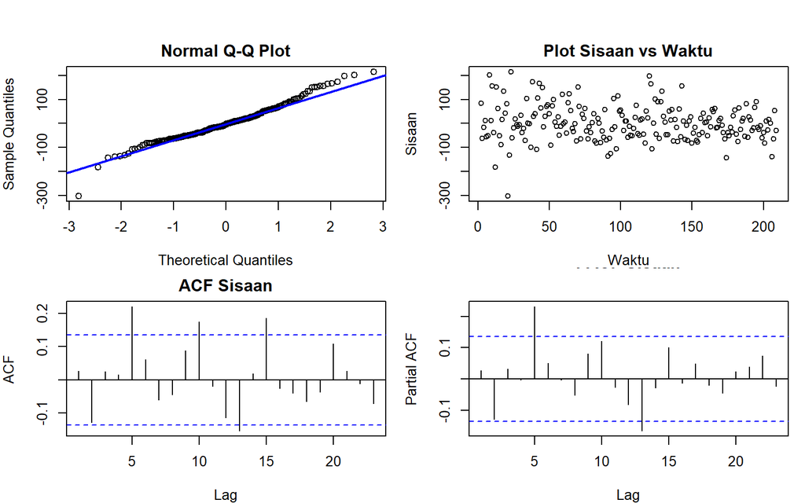

```r
sisaan.da <- model3.da$residuals

par(mfrow = c(2,2), mar = c(4,4,2,1), oma = c(0,0,2,0))
qqnorm(sisaan.da, main = "Normal Q-Q Plot")
qqline(sisaan.da, col = "blue", lwd = 2)
plot(sisaan.da, type = "p", main = "Plot Sisaan vs Waktu",
     xlab = "Waktu", ylab = "Sisaan")
acf(sisaan.da, main = "ACF Sisaan")
pacf(sisaan.da, main = "PACF Sisaan")
```

Secara eksploratif, Normal Q-Q Plot menunjukkan bahwa sebagian besar sisaan mengikuti garis diagonal, meskipun terdapat penyimpangan pada bagian ekor. Plot sisaan terhadap waktu menunjukkan bahwa sisaan menyebar di sekitar nol tanpa pola sistematis yang jelas. Sementara itu, ACF dan PACF sisaan menunjukkan bahwa sebagian besar spike berada dalam batas interval kepercayaan, meskipun terdapat beberapa spike yang melewati batas. Oleh karena itu, kenormalan dan independensi sisaan perlu dikonfirmasi lebih lanjut menggunakan pengujian formal.

### Uji Formal

```r
#1) Sisaan Menyebar Normal
ks.test(sisaan.da, "pnorm")  #gagal tolak H0 > sisaan saling bebas
```

```
##
##  Asymptotic one-sample Kolmogorov-Smirnov test
##
## data:  sisaan.da
## D = 0.5, p-value < 2.2e-16
## alternative hypothesis: two-sided
```

```r
shapiro.test(sisaan.da)
```

```
##
##  Shapiro-Wilk normality test
##
## data:  sisaan.da
## W = 0.97402, p-value = 0.0006832
```

Selain dengan eksplorasi, asumsi tersebut dapat diuji menggunakan uji formal. Pada tahapan ini uji formal yang digunakan untuk normalitas adalah uji Kolmogorov-Smirnov (KS). Hipotesis pada uji KS adalah sebagai berikut.

$H_0$ : Sisaan menyebar normal $H_1$ : Sisaan tidak menyebar normal

Berdasarkan uji KS tersebut, didapat *p-value* sebesar 2.2e-16 yang kurang dari taraf nyata 5% sehingga tolak $H_0$ dan menandakan bahwa sisaan tidak menyebar normal. Hal ini sesuai dengan hasil eksplorasi menggunakan plot kuantil-kuantil normal.

```r
#2) Sisaan saling bebas/tidak ada autokorelasi
Box.test(sisaan.da, type = "Ljung")  #gagal tolak H0 > sisaan saling bebas
```

```
##
##  Box-Ljung test
##
## data:  sisaan.da
## X-squared = 0.14552, df = 1, p-value = 0.7029
```

Selanjutnya akan dilakukan uji formal untuk kebebasan sisaan menggunakan uji Ljung-Box. Hipotesis yang digunakan adalah sebagai berikut.

$H_0$ : Sisaan saling bebas $H_1$ : Sisaan tidak tidak saling bebas

Berdasarkan uji Ljung-Box tersebut, didapat *p-value* sebesar 0.7029 yang lebih besar dari taraf nyata 5% sehingga gagal tolak $H_0$ dan menandakan bahwa sisaan saling bebas. Hal ini menunjukkan bahwa tidak terdapat bukti yang cukup untuk menyatakan adanya autokorelasi pada sisaan, sehingga sisaan dapat dianggap saling bebas. Hasil uji formal ini berbeda dengan kesan eksploratif pada plot ACF dan PACF, yang menunjukkan adanya beberapa spike yang melewati batas interval kepercayaan. Dengan demikian, berdasarkan uji formal Ljung-Box, asumsi kebebasan sisaan dapat dianggap terpenuhi.

```r
#3) Sisaan homogen
Box.test((sisaan.da)^2, type = "Ljung")  #gagal tolak H0 > sisaan homogen
```

```
##
##  Box-Ljung test
##
## data:  (sisaan.da)^2
## X-squared = 4.5455, df = 1, p-value = 0.03301
```

Hipotesis yang digunakan untuk uji kehomogenan ragam adalah sebagai berikut.

$H_0$ : Ragam sisaan homogen $H_1$ : Ragam sisaan tidak homogen

```r
#4) Nilai tengah sisaan sama dengan nol
t.test(sisaan.da, mu = 0, conf.level = 0.95)  #gagal tolak h0 > nilai tengah sisaan sama dengan 0
```

```
##
##  One Sample t-test
##
## data:  sisaan.da
## t = 0.34708, df = 207, p-value = 0.7289
## alternative hypothesis: true mean is not equal to 0
## 95 percent confidence interval:
##  -8.252047 11.778447
## sample estimates:
## mean of x
##    1.7632
```

Terakhir, dengan uji-t, akan dicek apakah nilai tengah sisaan sama dengan nol. Hipotesis yang diujikan sebagai berikut.

$H_0$ : nilai tengah sisaan sama dengan 0 $H_1$ : nilai tengah sisaan tidak sama dengan 0

Berdasarkan uji-ttersebut, didapat *p-value* sebesar 0.7289 yang lebih besar dari taraf nyata 5% sehingga gagal tolak $H_0$ dan menandakan bahwa nilai tengah sisaan sama dengan nol.

## Overfitting

```r
overfitting_da <- data.frame(
  Model = c("ARIMA(1,1,1)","ARIMA(2,1,1)","ARIMA(1,1,2)"),
  AIC   = c(AIC(model3.da), AIC(model5.da), AIC(model4.da)),
  BIC   = c(BIC(model3.da), BIC(model5.da), BIC(model4.da))
)
overfitting_da
```

```
##          Model      AIC      BIC
## 1 ARIMA(1,1,1) 2381.952 2391.965
## 2 ARIMA(2,1,1) 2378.336 2391.686
## 3 ARIMA(1,1,2) 2377.589 2390.939
```

### Model Terbaik: ARIMA(1,1,1)

```r
model.final <- forecast::Arima(train.ts, order = c(1,1,1), method = "ML")
summary(model.final)
```

```
## Series: train.ts
## ARIMA(1,1,1)
##
## Coefficients:
##          ar1      ma1
##       0.2397  -0.6142
## s.e.  0.1166   0.0863
##
## sigma^2 = 5398:  log likelihood = -1187.98
## AIC=2381.95   AICc=2382.07   BIC=2391.96
##
## Training set error measures:
##                    ME     RMSE      MAE        MPE      MAPE      MASE
## Training set 1.821476 72.94155 55.59617 0.01102673 0.3890248 0.9512731
##                    ACF1
## Training set 0.02715609
```

```r
lmtest::coeftest(model.final)
```

```
##
## z test of coefficients:
##
##      Estimate Std. Error z value  Pr(>|z|)
## ar1  0.239665   0.116556  2.0562   0.03976 *
## ma1 -0.614245   0.086276 -7.1196 1.083e-12 ***
## ---
## Signif. codes:  0 '***' 0.001 '**' 0.01 '*' 0.05 '.' 0.1 ' ' 1
```

## Peramalan

```r
ramalan.da <- forecast::forecast(model.final, h = length(test.ts))
ramalan.da
```

```
##     Point Forecast    Lo 80    Hi 80    Lo 95    Hi 95
## 210       14124.85 14030.69 14219.00 13980.85 14268.85
## 211       14126.78 14015.72 14237.83 13956.93 14296.62
## 212       14127.24 14005.27 14249.21 13940.70 14313.78
## 213       14127.35 13996.12 14258.58 13926.66 14328.04
## 214       14127.38 13987.67 14267.08 13913.72 14341.03
## 215       14127.38 13979.73 14275.04 13901.56 14353.20
## 216       14127.38 13972.19 14282.58 13890.04 14364.73
## 217       14127.38 13965.00 14289.77 13879.05 14375.72
## 218       14127.38 13958.12 14296.65 13868.52 14386.25
## 219       14127.38 13951.51 14303.26 13858.41 14396.36
## 220       14127.38 13945.14 14309.63 13848.66 14406.11
## 221       14127.38 13938.98 14315.79 13839.25 14415.52
## 222       14127.38 13933.02 14321.75 13830.13 14424.64
## 223       14127.38 13927.24 14327.53 13821.28 14433.49
```

[output cut: 38 more lines]

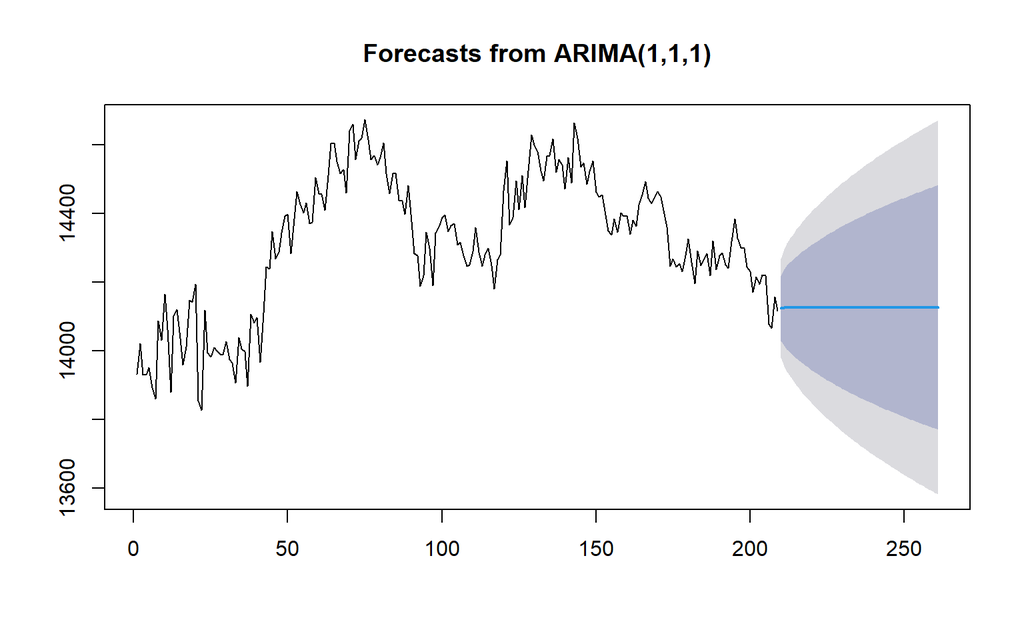

```r
# Nilai hasil ramalan
data.ramalan.da <- ramalan.da$mean

# Plot
plot(ramalan.da)
```

```r
data.ramalan.da <- as.numeric(ramalan.da$mean)
hasil <- data.ramalan.da

perbandingan.da <- cbind(
  Aktual   = as.numeric(test.ts),
  Forecast = round(hasil, 2)
)
print(perbandingan.da)
```

```
##        Aktual Forecast
##  [1,] 14119.8 14124.85
##  [2,] 14175.0 14126.78
##  [3,] 14116.0 14127.24
##  [4,] 14193.5 14127.35
##  [5,] 14175.7 14127.38
##  [6,] 14217.1 14127.38
##  [7,] 14229.0 14127.38
##  [8,] 14228.5 14127.38
##  [9,] 14276.6 14127.38
## [10,] 14289.9 14127.38
## [11,] 14366.0 14127.38
## [12,] 14414.0 14127.38
## [13,] 14319.8 14127.38
## [14,] 14252.0 14127.38
```

[output cut: 38 more lines]

```r
akurasi_test <- accuracy(hasil, as.numeric(test.ts))
akurasi_test
```

```
##                ME     RMSE      MAE      MPE     MAPE
## Test set 160.3004 182.9901 160.9269 1.118183 1.122621
```

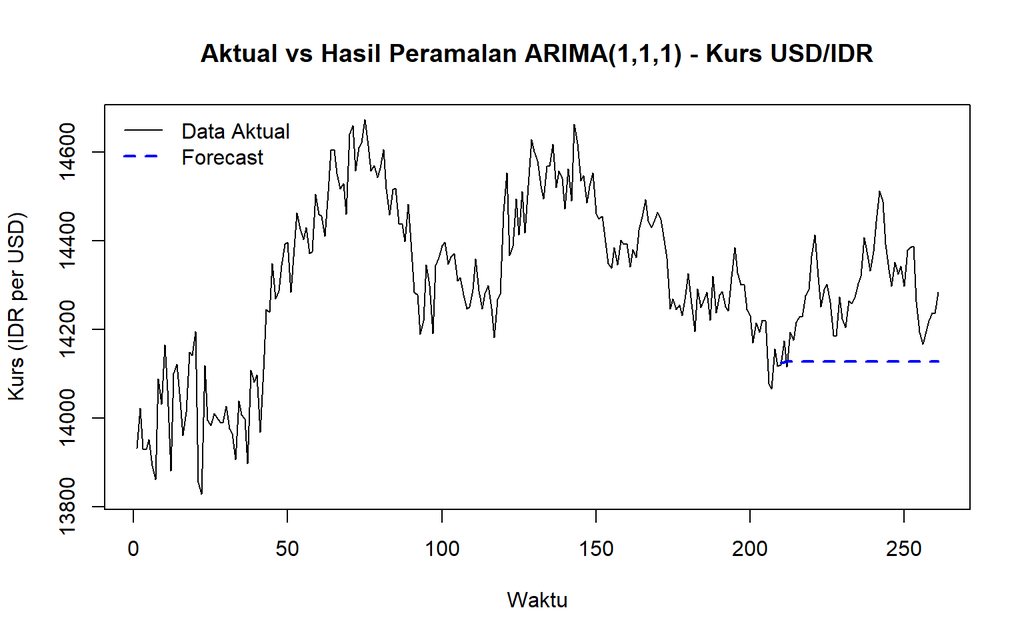

```r
ts.plot(data.ts, col = "black", lty = 1,
        xlab = "Waktu", ylab = "Kurs (IDR per USD)",
        main = "Aktual vs Hasil Peramalan ARIMA(1,1,1) - Kurs USD/IDR")
lines((n_train+1):(n_train+length(hasil)), hasil, col = "blue", lty = 2, lwd = 2)
legend("topleft", legend = c("Data Aktual", "Forecast"),
       col = c("black", "blue"), lty = c(1,2), lwd = c(1,2), bty = "n")
```